# Risk Factor Analysis

## Outcome Variable

**Outcome Variable:** swasted

## Predictor Variables

**Intervention Variable:** feducyrs

**Adjustment Set:**

- arm
- W_mage
- meducyrs
- hhwealth_quart
- W_mhtcm
- W_mwtkg
- W_mbmi
- W_gagebrth
- W_birthwt
- W_birthlen
- single
- delta_W_mage
- delta_meducyrs
- delta_hhwealth_quart
- delta_W_mhtcm
- delta_W_mwtkg
- delta_W_mbmi
- delta_W_gagebrth
- delta_W_birthwt
- delta_W_birthlen
- delta_single

## Stratifying Variables

The analysis was stratified on these variable(s):

- agecat
- studyid
- country

## Data Summary

| agecat | studyid | country | feducyrs | swasted | n_cell | n |
| --- | --- | --- | --- | --- | --- | --- |
| Birth | COHORTS | GUATEMALA | High | 0 | 125 | 718 |
| Birth | COHORTS | GUATEMALA | High | 1 | 11 | 718 |
| Birth | COHORTS | GUATEMALA | Low | 0 | 287 | 718 |
| Birth | COHORTS | GUATEMALA | Low | 1 | 24 | 718 |
| Birth | COHORTS | GUATEMALA | Medium | 0 | 252 | 718 |
| Birth | COHORTS | GUATEMALA | Medium | 1 | 19 | 718 |
| Birth | COHORTS | INDIA | High | 0 | 481 | 1291 |
| Birth | COHORTS | INDIA | High | 1 | 26 | 1291 |
| Birth | COHORTS | INDIA | Low | 0 | 407 | 1291 |
| Birth | COHORTS | INDIA | Low | 1 | 7 | 1291 |
| Birth | COHORTS | INDIA | Medium | 0 | 349 | 1291 |
| Birth | COHORTS | INDIA | Medium | 1 | 21 | 1291 |
| Birth | COHORTS | PHILIPPINES | High | 0 | 945 | 2728 |
| Birth | COHORTS | PHILIPPINES | High | 1 | 49 | 2728 |
| Birth | COHORTS | PHILIPPINES | Low | 0 | 753 | 2728 |
| Birth | COHORTS | PHILIPPINES | Low | 1 | 20 | 2728 |
| Birth | COHORTS | PHILIPPINES | Medium | 0 | 919 | 2728 |
| Birth | COHORTS | PHILIPPINES | Medium | 1 | 42 | 2728 |
| Birth | GMS-Nepal | NEPAL | High | 0 | 151 | 640 |
| Birth | GMS-Nepal | NEPAL | High | 1 | 11 | 640 |
| Birth | GMS-Nepal | NEPAL | Low | 0 | 259 | 640 |
| Birth | GMS-Nepal | NEPAL | Low | 1 | 7 | 640 |
| Birth | GMS-Nepal | NEPAL | Medium | 0 | 203 | 640 |
| Birth | GMS-Nepal | NEPAL | Medium | 1 | 9 | 640 |
| Birth | JiVitA-3 | BANGLADESH | High | 0 | 3965 | 17367 |
| Birth | JiVitA-3 | BANGLADESH | High | 1 | 84 | 17367 |
| Birth | JiVitA-3 | BANGLADESH | Low | 0 | 7312 | 17367 |
| Birth | JiVitA-3 | BANGLADESH | Low | 1 | 140 | 17367 |
| Birth | JiVitA-3 | BANGLADESH | Medium | 0 | 5760 | 17367 |
| Birth | JiVitA-3 | BANGLADESH | Medium | 1 | 106 | 17367 |

[output cut: 300 more lines]

The following strata were considered:

- agecat: 24 months, studyid: COHORTS, country: GUATEMALA
- agecat: 24 months, studyid: COHORTS, country: INDIA
- agecat: 24 months, studyid: COHORTS, country: PHILIPPINES
- agecat: 24 months, studyid: GMS-Nepal, country: NEPAL
- agecat: 24 months, studyid: JiVitA-3, country: BANGLADESH
- agecat: 24 months, studyid: JiVitA-4, country: BANGLADESH
- agecat: 24 months, studyid: LCNI-5, country: MALAWI
- agecat: 24 months, studyid: MAL-ED, country: BANGLADESH
- agecat: 24 months, studyid: MAL-ED, country: INDIA
- agecat: 24 months, studyid: MAL-ED, country: NEPAL
- agecat: 24 months, studyid: MAL-ED, country: PERU
- agecat: 24 months, studyid: MAL-ED, country: SOUTH AFRICA
- agecat: 24 months, studyid: MAL-ED, country: TANZANIA, UNITED REPUBLIC OF
- agecat: 24 months, studyid: NIH-Crypto, country: BANGLADESH
- agecat: 24 months, studyid: PROBIT, country: BELARUS
- agecat: 24 months, studyid: PROVIDE, country: BANGLADESH
- agecat: 24 months, studyid: TanzaniaChild2, country: TANZANIA, UNITED REPUBLIC OF
- agecat: 24 months, studyid: ZVITAMBO, country: ZIMBABWE
- agecat: 6 months, studyid: COHORTS, country: GUATEMALA
- agecat: 6 months, studyid: COHORTS, country: INDIA
- agecat: 6 months, studyid: COHORTS, country: PHILIPPINES
- agecat: 6 months, studyid: GMS-Nepal, country: NEPAL
- agecat: 6 months, studyid: JiVitA-3, country: BANGLADESH
- agecat: 6 months, studyid: JiVitA-4, country: BANGLADESH
- agecat: 6 months, studyid: LCNI-5, country: MALAWI
- agecat: 6 months, studyid: MAL-ED, country: BANGLADESH
- agecat: 6 months, studyid: MAL-ED, country: INDIA
- agecat: 6 months, studyid: MAL-ED, country: NEPAL
- agecat: 6 months, studyid: MAL-ED, country: PERU
- agecat: 6 months, studyid: MAL-ED, country: SOUTH AFRICA
- agecat: 6 months, studyid: MAL-ED, country: TANZANIA, UNITED REPUBLIC OF
- agecat: 6 months, studyid: NIH-Crypto, country: BANGLADESH
- agecat: 6 months, studyid: PROBIT, country: BELARUS
- agecat: 6 months, studyid: PROVIDE, country: BANGLADESH
- agecat: 6 months, studyid: SAS-CompFeed, country: INDIA
- agecat: 6 months, studyid: SAS-FoodSuppl, country: INDIA
- agecat: 6 months, studyid: TanzaniaChild2, country: TANZANIA, UNITED REPUBLIC OF
- agecat: 6 months, studyid: ZVITAMBO, country: ZIMBABWE
- agecat: Birth, studyid: COHORTS, country: GUATEMALA
- agecat: Birth, studyid: COHORTS, country: INDIA
- agecat: Birth, studyid: COHORTS, country: PHILIPPINES
- agecat: Birth, studyid: GMS-Nepal, country: NEPAL
- agecat: Birth, studyid: JiVitA-3, country: BANGLADESH
- agecat: Birth, studyid: JiVitA-4, country: BANGLADESH
- agecat: Birth, studyid: MAL-ED, country: BANGLADESH
- agecat: Birth, studyid: MAL-ED, country: INDIA
- agecat: Birth, studyid: MAL-ED, country: NEPAL
- agecat: Birth, studyid: MAL-ED, country: PERU
- agecat: Birth, studyid: MAL-ED, country: SOUTH AFRICA
- agecat: Birth, studyid: MAL-ED, country: TANZANIA, UNITED REPUBLIC OF
- agecat: Birth, studyid: NIH-Crypto, country: BANGLADESH
- agecat: Birth, studyid: PROBIT, country: BELARUS
- agecat: Birth, studyid: PROVIDE, country: BANGLADESH
- agecat: Birth, studyid: SAS-CompFeed, country: INDIA
- agecat: Birth, studyid: ZVITAMBO, country: ZIMBABWE

### Dropped Strata

Some strata were dropped due to rare outcomes:

- agecat: Birth, studyid: MAL-ED, country: BANGLADESH
- agecat: Birth, studyid: MAL-ED, country: INDIA
- agecat: Birth, studyid: MAL-ED, country: NEPAL
- agecat: Birth, studyid: MAL-ED, country: PERU
- agecat: Birth, studyid: MAL-ED, country: SOUTH AFRICA
- agecat: Birth, studyid: MAL-ED, country: TANZANIA, UNITED REPUBLIC OF
- agecat: Birth, studyid: PROVIDE, country: BANGLADESH
- agecat: 6 months, studyid: COHORTS, country: GUATEMALA
- agecat: 6 months, studyid: GMS-Nepal, country: NEPAL
- agecat: 6 months, studyid: JiVitA-4, country: BANGLADESH
- agecat: 6 months, studyid: LCNI-5, country: MALAWI
- agecat: 6 months, studyid: MAL-ED, country: BANGLADESH
- agecat: 6 months, studyid: MAL-ED, country: INDIA
- agecat: 6 months, studyid: MAL-ED, country: NEPAL
- agecat: 6 months, studyid: MAL-ED, country: PERU
- agecat: 6 months, studyid: MAL-ED, country: SOUTH AFRICA
- agecat: 6 months, studyid: MAL-ED, country: TANZANIA, UNITED REPUBLIC OF
- agecat: 6 months, studyid: NIH-Crypto, country: BANGLADESH
- agecat: 6 months, studyid: PROBIT, country: BELARUS
- agecat: 6 months, studyid: PROVIDE, country: BANGLADESH
- agecat: 6 months, studyid: TanzaniaChild2, country: TANZANIA, UNITED REPUBLIC OF
- agecat: 24 months, studyid: COHORTS, country: GUATEMALA
- agecat: 24 months, studyid: COHORTS, country: INDIA
- agecat: 24 months, studyid: COHORTS, country: PHILIPPINES
- agecat: 24 months, studyid: GMS-Nepal, country: NEPAL
- agecat: 24 months, studyid: LCNI-5, country: MALAWI
- agecat: 24 months, studyid: MAL-ED, country: BANGLADESH
- agecat: 24 months, studyid: MAL-ED, country: INDIA
- agecat: 24 months, studyid: MAL-ED, country: NEPAL
- agecat: 24 months, studyid: MAL-ED, country: PERU
- agecat: 24 months, studyid: MAL-ED, country: SOUTH AFRICA
- agecat: 24 months, studyid: MAL-ED, country: TANZANIA, UNITED REPUBLIC OF
- agecat: 24 months, studyid: NIH-Crypto, country: BANGLADESH
- agecat: 24 months, studyid: PROBIT, country: BELARUS
- agecat: 24 months, studyid: PROVIDE, country: BANGLADESH
- agecat: 24 months, studyid: TanzaniaChild2, country: TANZANIA, UNITED REPUBLIC OF
- agecat: 24 months, studyid: ZVITAMBO, country: ZIMBABWE

## Methods Detail

We’re interested in the causal parameters $E[Y_a]$ for all values of $a \in \mathcal{A}$. These parameters represent the mean outcome if, possibly contrary to fact, we intervened to set all units to have $A=a$. Under the randomization and positivity assumptions, these are identified by the statistical parameters $\psi_a=E_W[E_{Y|A,W}(Y|A=a,W)]$. In addition, we’re interested in the mean of $Y$, $E[Y]$ under no intervention (the observed mean). We will estimate these parameters by using SuperLearner to fit the relevant likelihood factors – $E_{Y|A,W}(Y|A=a,W)$ and $p(A=a|W)$, and then updating our likelihood fit using a joint TMLE.

For unadjusted analyses ($W=\{\}$), initial likelihoods were estimated using Lrnr_glm to estimate the simple $E(Y|A)$ and Lrnr_mean to estimate $p(A)$. For adjusted analyses, a small library containing Lrnr_glmnet, Lrnr_xgboost, and Lrnr_mean was used.

Having estimated these parameters, we will then use the delta method to estimate relative risks and attributable risks relative to a prespecified baseline level of $A$.

# Results Detail

## Results Plots

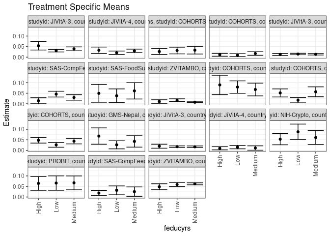

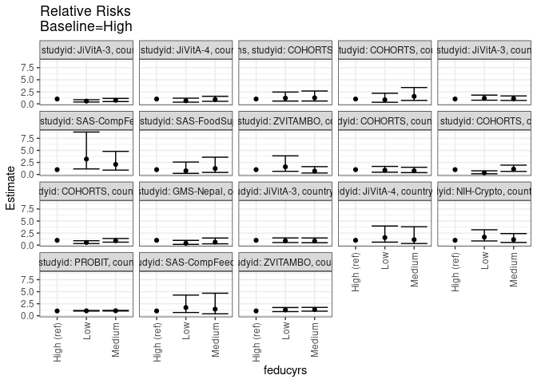

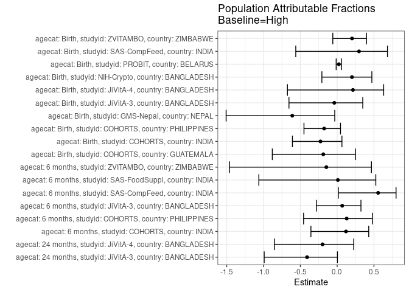

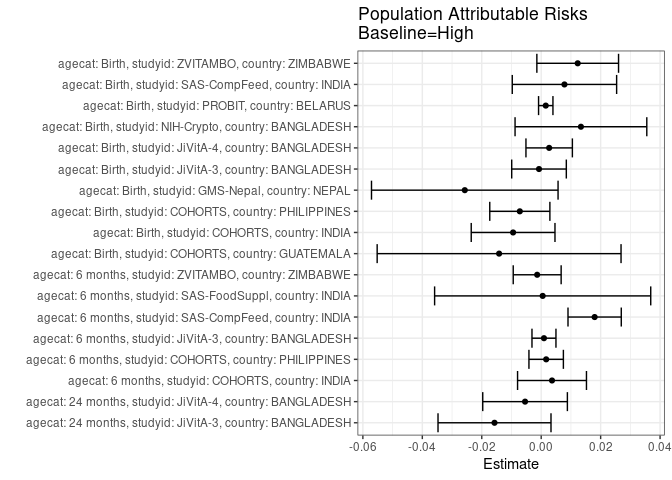

## Results Table

### Parameter: TSM

| agecat | studyid | country | intervention_level | baseline_level | estimate | ci_lower | ci_upper |
| --- | --- | --- | --- | --- | --- | --- | --- |
| Birth | COHORTS | GUATEMALA | High | NA | 0.0893733 | 0.0433017 | 0.1354449 |
| Birth | COHORTS | GUATEMALA | Low | NA | 0.0791725 | 0.0497125 | 0.1086326 |
| Birth | COHORTS | GUATEMALA | Medium | NA | 0.0676203 | 0.0372992 | 0.0979414 |
| Birth | COHORTS | INDIA | High | NA | 0.0512821 | 0.0320749 | 0.0704892 |
| Birth | COHORTS | INDIA | Low | NA | 0.0169082 | 0.0044842 | 0.0293322 |
| Birth | COHORTS | INDIA | Medium | NA | 0.0567568 | 0.0331717 | 0.0803418 |
| Birth | COHORTS | PHILIPPINES | High | NA | 0.0478824 | 0.0345426 | 0.0612222 |
| Birth | COHORTS | PHILIPPINES | Low | NA | 0.0260858 | 0.0148456 | 0.0373260 |
| Birth | COHORTS | PHILIPPINES | Medium | NA | 0.0437151 | 0.0306917 | 0.0567384 |
| Birth | GMS-Nepal | NEPAL | High | NA | 0.0679012 | 0.0291309 | 0.1066716 |
| Birth | GMS-Nepal | NEPAL | Low | NA | 0.0263158 | 0.0070643 | 0.0455673 |
| Birth | GMS-Nepal | NEPAL | Medium | NA | 0.0424528 | 0.0152914 | 0.0696143 |
| Birth | JiVitA-3 | BANGLADESH | High | NA | 0.0197374 | 0.0102324 | 0.0292425 |
| Birth | JiVitA-3 | BANGLADESH | Low | NA | 0.0175930 | 0.0139135 | 0.0212725 |
| Birth | JiVitA-3 | BANGLADESH | Medium | NA | 0.0169023 | 0.0128243 | 0.0209803 |
| Birth | JiVitA-4 | BANGLADESH | High | NA | 0.0098039 | 0.0022932 | 0.0173147 |
| Birth | JiVitA-4 | BANGLADESH | Low | NA | 0.0153341 | 0.0072544 | 0.0234137 |
| Birth | JiVitA-4 | BANGLADESH | Medium | NA | 0.0111111 | 0.0007252 | 0.0214971 |
| Birth | NIH-Crypto | BANGLADESH | High | NA | 0.0531111 | 0.0264568 | 0.0797654 |
| Birth | NIH-Crypto | BANGLADESH | Low | NA | 0.0879860 | 0.0513081 | 0.1246638 |
| Birth | NIH-Crypto | BANGLADESH | Medium | NA | 0.0608982 | 0.0280474 | 0.0937490 |
| Birth | PROBIT | BELARUS | High | NA | 0.0642353 | 0.0316761 | 0.0967945 |
| Birth | PROBIT | BELARUS | Low | NA | 0.0659888 | 0.0317609 | 0.1002167 |
| Birth | PROBIT | BELARUS | Medium | NA | 0.0669559 | 0.0340242 | 0.0998875 |
| Birth | SAS-CompFeed | INDIA | High | NA | 0.0185185 | 0.0065073 | 0.0305297 |
| Birth | SAS-CompFeed | INDIA | Low | NA | 0.0315126 | 0.0105174 | 0.0525078 |
| Birth | SAS-CompFeed | INDIA | Medium | NA | 0.0253521 | 0.0030904 | 0.0476138 |
| Birth | ZVITAMBO | ZIMBABWE | High | NA | 0.0484837 | 0.0343058 | 0.0626615 |
| Birth | ZVITAMBO | ZIMBABWE | Low | NA | 0.0590319 | 0.0488814 | 0.0691824 |
| Birth | ZVITAMBO | ZIMBABWE | Medium | NA | 0.0623597 | 0.0575450 | 0.0671745 |
| 6 months | COHORTS | INDIA | High | NA | 0.0266861 | 0.0126620 | 0.0407102 |
| 6 months | COHORTS | INDIA | Low | NA | 0.0314684 | 0.0155614 | 0.0473754 |
| 6 months | COHORTS | INDIA | Medium | NA | 0.0331622 | 0.0149312 | 0.0513933 |
| 6 months | COHORTS | PHILIPPINES | High | NA | 0.0112108 | 0.0043001 | 0.0181214 |
| 6 months | COHORTS | PHILIPPINES | Low | NA | 0.0094086 | 0.0024703 | 0.0163470 |
| 6 months | COHORTS | PHILIPPINES | Medium | NA | 0.0172786 | 0.0088841 | 0.0256732 |
| 6 months | JiVitA-3 | BANGLADESH | High | NA | 0.0126673 | 0.0079577 | 0.0173769 |
| 6 months | JiVitA-3 | BANGLADESH | Low | NA | 0.0147897 | 0.0113443 | 0.0182351 |
| 6 months | JiVitA-3 | BANGLADESH | Medium | NA | 0.0134897 | 0.0102556 | 0.0167239 |
| 6 months | SAS-CompFeed | INDIA | High | NA | 0.0143266 | 0.0000589 | 0.0285944 |
| 6 months | SAS-CompFeed | INDIA | Low | NA | 0.0456204 | 0.0318281 | 0.0594127 |
| 6 months | SAS-CompFeed | INDIA | Medium | NA | 0.0299539 | 0.0168697 | 0.0430382 |
| 6 months | SAS-FoodSuppl | INDIA | High | NA | 0.0495050 | 0.0071447 | 0.0918652 |
| 6 months | SAS-FoodSuppl | INDIA | Low | NA | 0.0378788 | 0.0052691 | 0.0704884 |
| 6 months | SAS-FoodSuppl | INDIA | Medium | NA | 0.0612245 | 0.0224179 | 0.1000310 |
| 6 months | ZVITAMBO | ZIMBABWE | High | NA | 0.0105448 | 0.0021515 | 0.0189382 |
| 6 months | ZVITAMBO | ZIMBABWE | Low | NA | 0.0167481 | 0.0101035 | 0.0233926 |
| 6 months | ZVITAMBO | ZIMBABWE | Medium | NA | 0.0073436 | 0.0052291 | 0.0094580 |
| 24 months | JiVitA-3 | BANGLADESH | High | NA | 0.0541913 | 0.0339178 | 0.0744649 |
| 24 months | JiVitA-3 | BANGLADESH | Low | NA | 0.0306894 | 0.0247670 | 0.0366118 |
| 24 months | JiVitA-3 | BANGLADESH | Medium | NA | 0.0393706 | 0.0301469 | 0.0485943 |
| 24 months | JiVitA-4 | BANGLADESH | High | NA | 0.0328095 | 0.0176968 | 0.0479223 |
| 24 months | JiVitA-4 | BANGLADESH | Low | NA | 0.0209060 | 0.0127840 | 0.0290279 |
| 24 months | JiVitA-4 | BANGLADESH | Medium | NA | 0.0296933 | 0.0212317 | 0.0381548 |

### Parameter: E(Y)

| agecat | studyid | country | intervention_level | baseline_level | estimate | ci_lower | ci_upper |
| --- | --- | --- | --- | --- | --- | --- | --- |
| Birth | COHORTS | GUATEMALA | NA | NA | 0.0752089 | 0.0559050 | 0.0945128 |
| Birth | COHORTS | INDIA | NA | NA | 0.0418280 | 0.0309034 | 0.0527527 |
| Birth | COHORTS | PHILIPPINES | NA | NA | 0.0406891 | 0.0332739 | 0.0481044 |
| Birth | GMS-Nepal | NEPAL | NA | NA | 0.0421875 | 0.0266017 | 0.0577733 |
| Birth | JiVitA-3 | BANGLADESH | NA | NA | 0.0190016 | 0.0166360 | 0.0213671 |
| Birth | JiVitA-4 | BANGLADESH | NA | NA | 0.0124839 | 0.0071213 | 0.0178464 |
| Birth | NIH-Crypto | BANGLADESH | NA | NA | 0.0664781 | 0.0481022 | 0.0848539 |
| Birth | PROBIT | BELARUS | NA | NA | 0.0657678 | 0.0327531 | 0.0987825 |
| Birth | SAS-CompFeed | INDIA | NA | NA | 0.0263397 | 0.0123159 | 0.0403635 |
| Birth | ZVITAMBO | ZIMBABWE | NA | NA | 0.0607651 | 0.0565891 | 0.0649411 |
| 6 months | COHORTS | INDIA | NA | NA | 0.0303249 | 0.0212906 | 0.0393592 |
| 6 months | COHORTS | PHILIPPINES | NA | NA | 0.0128806 | 0.0085134 | 0.0172477 |
| 6 months | JiVitA-3 | BANGLADESH | NA | NA | 0.0135983 | 0.0114298 | 0.0157667 |
| 6 months | SAS-CompFeed | INDIA | NA | NA | 0.0323065 | 0.0236135 | 0.0409996 |
| 6 months | SAS-FoodSuppl | INDIA | NA | NA | 0.0500000 | 0.0280580 | 0.0719420 |
| 6 months | ZVITAMBO | ZIMBABWE | NA | NA | 0.0091943 | 0.0071366 | 0.0112520 |
| 24 months | JiVitA-3 | BANGLADESH | NA | NA | 0.0384802 | 0.0340611 | 0.0428992 |
| 24 months | JiVitA-4 | BANGLADESH | NA | NA | 0.0273794 | 0.0221191 | 0.0326397 |

### Parameter: RR

| agecat | studyid | country | intervention_level | baseline_level | estimate | ci_lower | ci_upper |
| --- | --- | --- | --- | --- | --- | --- | --- |
| Birth | COHORTS | GUATEMALA | High | High | 1.0000000 | 1.0000000 | 1.0000000 |
| Birth | COHORTS | GUATEMALA | Low | High | 0.8858631 | 0.4705228 | 1.6678331 |
| Birth | COHORTS | GUATEMALA | Medium | High | 0.7566052 | 0.3826232 | 1.4961233 |
| Birth | COHORTS | INDIA | High | High | 1.0000000 | 1.0000000 | 1.0000000 |
| Birth | COHORTS | INDIA | Low | High | 0.3297101 | 0.1445278 | 0.7521652 |
| Birth | COHORTS | INDIA | Medium | High | 1.1067568 | 0.6325520 | 1.9364582 |
| Birth | COHORTS | PHILIPPINES | High | High | 1.0000000 | 1.0000000 | 1.0000000 |
| Birth | COHORTS | PHILIPPINES | Low | High | 0.5447894 | 0.3262624 | 0.9096833 |
| Birth | COHORTS | PHILIPPINES | Medium | High | 0.9129670 | 0.6074693 | 1.3721003 |
| Birth | GMS-Nepal | NEPAL | High | High | 1.0000000 | 1.0000000 | 1.0000000 |
| Birth | GMS-Nepal | NEPAL | Low | High | 0.3875598 | 0.1532184 | 0.9803170 |
| Birth | GMS-Nepal | NEPAL | Medium | High | 0.6252144 | 0.2652196 | 1.4738465 |
| Birth | JiVitA-3 | BANGLADESH | High | High | 1.0000000 | 1.0000000 | 1.0000000 |
| Birth | JiVitA-3 | BANGLADESH | Low | High | 0.8913517 | 0.5312572 | 1.4955238 |
| Birth | JiVitA-3 | BANGLADESH | Medium | High | 0.8563577 | 0.4949972 | 1.4815204 |
| Birth | JiVitA-4 | BANGLADESH | High | High | 1.0000000 | 1.0000000 | 1.0000000 |
| Birth | JiVitA-4 | BANGLADESH | Low | High | 1.5640745 | 0.6170812 | 3.9643549 |
| Birth | JiVitA-4 | BANGLADESH | Medium | High | 1.1333333 | 0.3365230 | 3.8168098 |
| Birth | NIH-Crypto | BANGLADESH | High | High | 1.0000000 | 1.0000000 | 1.0000000 |
| Birth | NIH-Crypto | BANGLADESH | Low | High | 1.6566386 | 0.8627403 | 3.1810863 |
| Birth | NIH-Crypto | BANGLADESH | Medium | High | 1.1466183 | 0.5491202 | 2.3942547 |
| Birth | PROBIT | BELARUS | High | High | 1.0000000 | 1.0000000 | 1.0000000 |
| Birth | PROBIT | BELARUS | Low | High | 1.0272978 | 0.9746855 | 1.0827500 |
| Birth | PROBIT | BELARUS | Medium | High | 1.0423530 | 0.9857467 | 1.1022098 |
| Birth | SAS-CompFeed | INDIA | High | High | 1.0000000 | 1.0000000 | 1.0000000 |
| Birth | SAS-CompFeed | INDIA | Low | High | 1.7016807 | 0.6748438 | 4.2909442 |
| Birth | SAS-CompFeed | INDIA | Medium | High | 1.3690141 | 0.4004177 | 4.6806116 |
| Birth | ZVITAMBO | ZIMBABWE | High | High | 1.0000000 | 1.0000000 | 1.0000000 |
| Birth | ZVITAMBO | ZIMBABWE | Low | High | 1.2175624 | 0.8677169 | 1.7084583 |
| Birth | ZVITAMBO | ZIMBABWE | Medium | High | 1.2862004 | 0.9511591 | 1.7392584 |
| 6 months | COHORTS | INDIA | High | High | 1.0000000 | 1.0000000 | 1.0000000 |
| 6 months | COHORTS | INDIA | Low | High | 1.1792056 | 0.5686726 | 2.4452132 |
| 6 months | COHORTS | INDIA | Medium | High | 1.2426783 | 0.5808418 | 2.6586402 |
| 6 months | COHORTS | PHILIPPINES | High | High | 1.0000000 | 1.0000000 | 1.0000000 |
| 6 months | COHORTS | PHILIPPINES | Low | High | 0.8392473 | 0.3209713 | 2.1943895 |
| 6 months | COHORTS | PHILIPPINES | Medium | High | 1.5412527 | 0.7030864 | 3.3786173 |
| 6 months | JiVitA-3 | BANGLADESH | High | High | 1.0000000 | 1.0000000 | 1.0000000 |
| 6 months | JiVitA-3 | BANGLADESH | Low | High | 1.1675536 | 0.7535289 | 1.8090632 |
| 6 months | JiVitA-3 | BANGLADESH | Medium | High | 1.0649295 | 0.6945648 | 1.6327849 |
| 6 months | SAS-CompFeed | INDIA | High | High | 1.0000000 | 1.0000000 | 1.0000000 |
| 6 months | SAS-CompFeed | INDIA | Low | High | 3.1843066 | 1.1506464 | 8.8122711 |
| 6 months | SAS-CompFeed | INDIA | Medium | High | 2.0907834 | 0.9108342 | 4.7993096 |
| 6 months | SAS-FoodSuppl | INDIA | High | High | 1.0000000 | 1.0000000 | 1.0000000 |
| 6 months | SAS-FoodSuppl | INDIA | Low | High | 0.7651515 | 0.2272994 | 2.5757078 |
| 6 months | SAS-FoodSuppl | INDIA | Medium | High | 1.2367347 | 0.4263944 | 3.5870847 |
| 6 months | ZVITAMBO | ZIMBABWE | High | High | 1.0000000 | 1.0000000 | 1.0000000 |
| 6 months | ZVITAMBO | ZIMBABWE | Low | High | 1.5882763 | 0.6526500 | 3.8651983 |
| 6 months | ZVITAMBO | ZIMBABWE | Medium | High | 0.6964134 | 0.2987164 | 1.6235851 |
| 24 months | JiVitA-3 | BANGLADESH | High | High | 1.0000000 | 1.0000000 | 1.0000000 |
| 24 months | JiVitA-3 | BANGLADESH | Low | High | 0.5663158 | 0.3759437 | 0.8530894 |
| 24 months | JiVitA-3 | BANGLADESH | Medium | High | 0.7265115 | 0.4698050 | 1.1234851 |
| 24 months | JiVitA-4 | BANGLADESH | High | High | 1.0000000 | 1.0000000 | 1.0000000 |
| 24 months | JiVitA-4 | BANGLADESH | Low | High | 0.6371918 | 0.3458930 | 1.1738120 |
| 24 months | JiVitA-4 | BANGLADESH | Medium | High | 0.9050186 | 0.5240145 | 1.5630459 |

### Parameter: PAR

| agecat | studyid | country | intervention_level | baseline_level | estimate | ci_lower | ci_upper |
| --- | --- | --- | --- | --- | --- | --- | --- |
| Birth | COHORTS | GUATEMALA | High | NA | -0.0141644 | -0.0551935 | 0.0268647 |
| Birth | COHORTS | INDIA | High | NA | -0.0094540 | -0.0235432 | 0.0046351 |
| Birth | COHORTS | PHILIPPINES | High | NA | -0.0071933 | -0.0173081 | 0.0029215 |
| Birth | GMS-Nepal | NEPAL | High | NA | -0.0257137 | -0.0570999 | 0.0056725 |
| Birth | JiVitA-3 | BANGLADESH | High | NA | -0.0007359 | -0.0099233 | 0.0084516 |
| Birth | JiVitA-4 | BANGLADESH | High | NA | 0.0026799 | -0.0051313 | 0.0104911 |
| Birth | NIH-Crypto | BANGLADESH | High | NA | 0.0133669 | -0.0087963 | 0.0355302 |
| Birth | PROBIT | BELARUS | High | NA | 0.0015325 | -0.0008860 | 0.0039510 |
| Birth | SAS-CompFeed | INDIA | High | NA | 0.0078212 | -0.0097372 | 0.0253795 |
| Birth | ZVITAMBO | ZIMBABWE | High | NA | 0.0122815 | -0.0014612 | 0.0260241 |
| 6 months | COHORTS | INDIA | High | NA | 0.0036388 | -0.0079529 | 0.0152305 |
| 6 months | COHORTS | PHILIPPINES | High | NA | 0.0016698 | -0.0041245 | 0.0074641 |
| 6 months | JiVitA-3 | BANGLADESH | High | NA | 0.0009310 | -0.0031034 | 0.0049654 |
| 6 months | SAS-CompFeed | INDIA | High | NA | 0.0179799 | 0.0090176 | 0.0269422 |
| 6 months | SAS-FoodSuppl | INDIA | High | NA | 0.0004950 | -0.0358640 | 0.0368541 |
| 6 months | ZVITAMBO | ZIMBABWE | High | NA | -0.0013505 | -0.0094118 | 0.0067107 |
| 24 months | JiVitA-3 | BANGLADESH | High | NA | -0.0157112 | -0.0347188 | 0.0032964 |
| 24 months | JiVitA-4 | BANGLADESH | High | NA | -0.0054301 | -0.0196699 | 0.0088096 |

### Parameter: PAF

| agecat | studyid | country | intervention_level | baseline_level | estimate | ci_lower | ci_upper |
| --- | --- | --- | --- | --- | --- | --- | --- |
| Birth | COHORTS | GUATEMALA | High | NA | -0.1883341 | -0.8808441 | 0.2491999 |
| Birth | COHORTS | INDIA | High | NA | -0.2260209 | -0.6075615 | 0.0649644 |
| Birth | COHORTS | PHILIPPINES | High | NA | -0.1767857 | -0.4506680 | 0.0453883 |
| Birth | GMS-Nepal | NEPAL | High | NA | -0.6095107 | -1.5083392 | -0.0327650 |
| Birth | JiVitA-3 | BANGLADESH | High | NA | -0.0387277 | -0.6544459 | 0.3478450 |
| Birth | JiVitA-4 | BANGLADESH | High | NA | 0.2146721 | -0.6753540 | 0.6318748 |
| Birth | NIH-Crypto | BANGLADESH | High | NA | 0.2010730 | -0.2074067 | 0.4713592 |
| Birth | PROBIT | BELARUS | High | NA | 0.0233015 | -0.0133800 | 0.0586553 |
| Birth | SAS-CompFeed | INDIA | High | NA | 0.2969349 | -0.5620029 | 0.6835470 |
| Birth | ZVITAMBO | ZIMBABWE | High | NA | 0.2021136 | -0.0590715 | 0.3988860 |
| 6 months | COHORTS | INDIA | High | NA | 0.1199939 | -0.3562121 | 0.4289899 |
| 6 months | COHORTS | PHILIPPINES | High | NA | 0.1296372 | -0.4558528 | 0.4796648 |
| 6 months | JiVitA-3 | BANGLADESH | High | NA | 0.0684644 | -0.2822126 | 0.3232335 |
| 6 months | SAS-CompFeed | INDIA | High | NA | 0.5565403 | 0.0163673 | 0.8000712 |
| 6 months | SAS-FoodSuppl | INDIA | High | NA | 0.0099010 | -1.0636802 | 0.5249768 |
| 6 months | ZVITAMBO | ZIMBABWE | High | NA | -0.1468874 | -1.4620659 | 0.4657532 |
| 24 months | JiVitA-3 | BANGLADESH | High | NA | -0.4082927 | -0.9911153 | 0.0039310 |
| 24 months | JiVitA-4 | BANGLADESH | High | NA | -0.1983296 | -0.8525032 | 0.2248360 |